# Analysis of Gas Receipts

Nathan Hoteling

January 2021

This analysis provides a summary of data collected from gas receipts for all vehicles I have owned from **April 2005** to **January 2021**, a span of **15.8** years. Over this time period we drove a total of **251,553** miles and spent **$24,702.94** on gas.

## Total Miles

The plot below shows the number of miles driven per month for all vehicles over this period. Note that gaps in the line chart represent months with no data; in some cases this was because we didn’t purchase gas during that month and in others it is because gas receipts were lost.

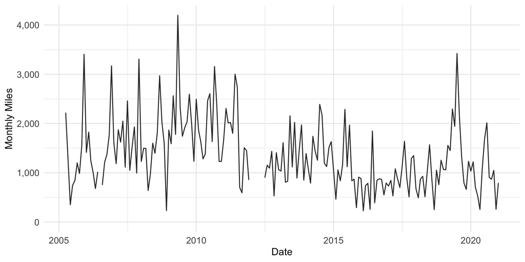

**Details: Seasonality**

There are some seasonal patterns in the number of miles driven over the course of the year.

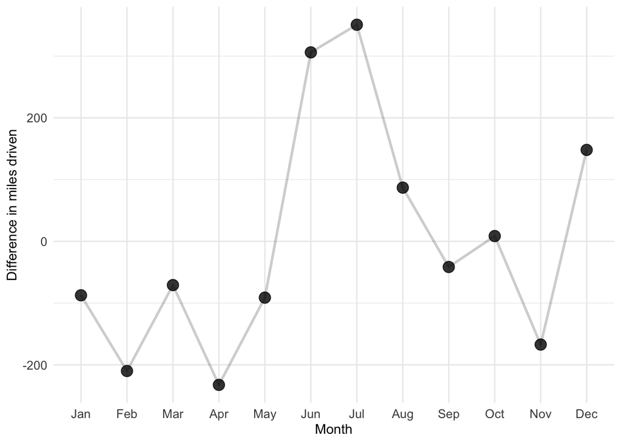

## Gas Mileage

The plot below shows the monthly gas mileage for each vehicle over this span. Each data point represents the monthly aggregate for a particular vehicle, and the curves are smoothed lines obtained from a time-series decomposition.

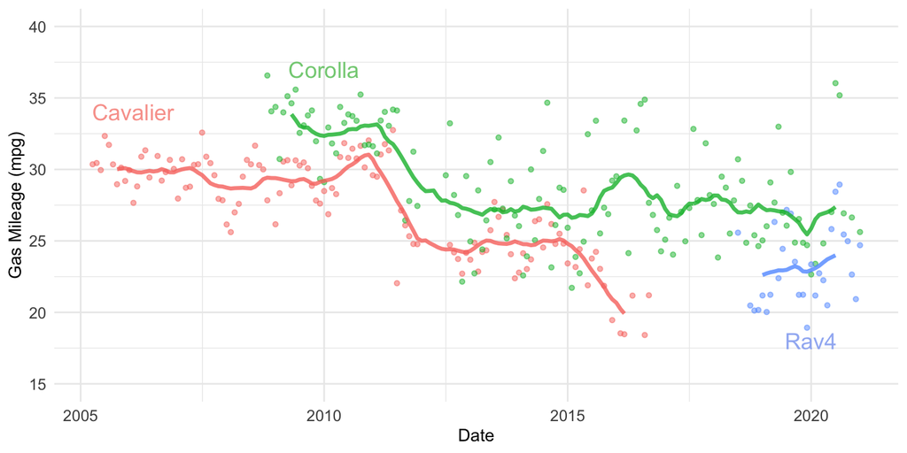

**Details: Gas Mileage**

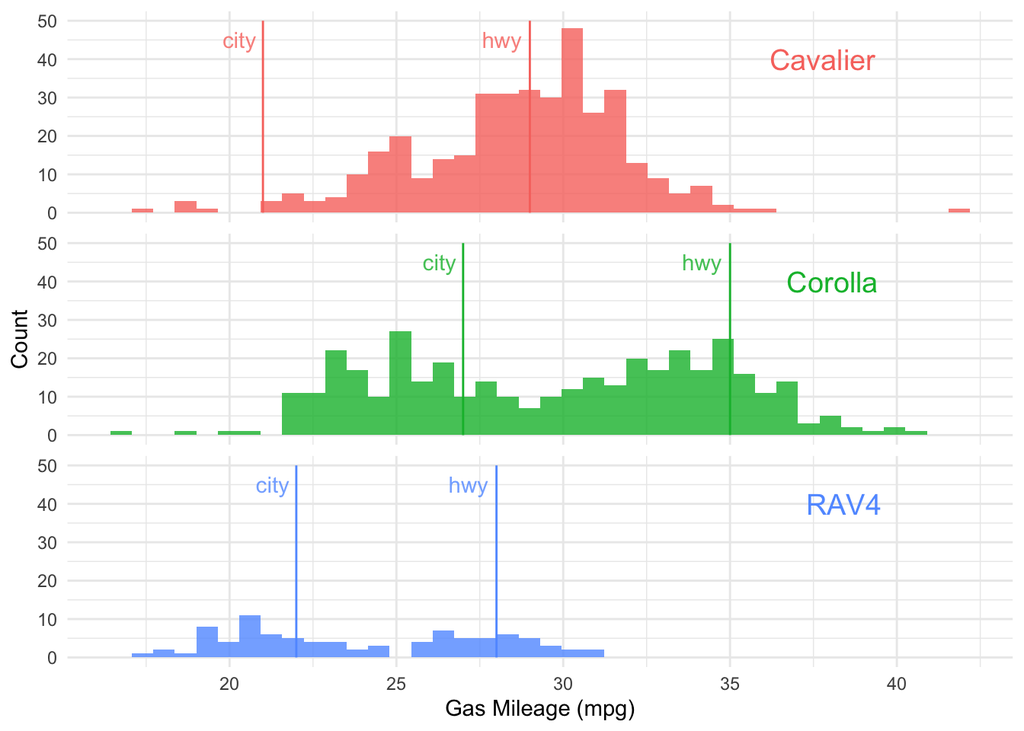

**Details: Seasonality**

Seasonal fluctuations in gas mileage were determined from a time series decomposition. The values vary for each vehicle:  
- For the **Cavalier** the magnitude is **2.9 mpg**  
- For the **Corolla** the magnitude is **6.8 mpg**  
- For the **RAV4** the magnitude is **8.2 mpg**

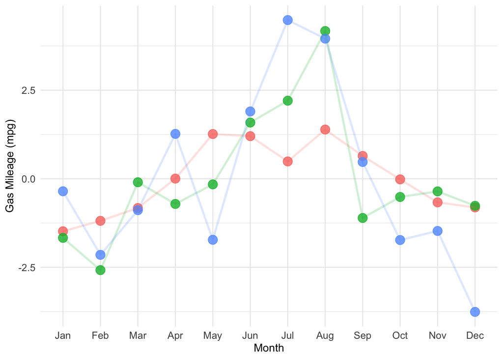

## Gas Prices

The plot below compares what we paid for gas with the national average monthly gas price according to https://www.eia.gov/. Each data point represents the monthly aggregate for all gas purchased during a particular month, and the trendline indicates the national average.

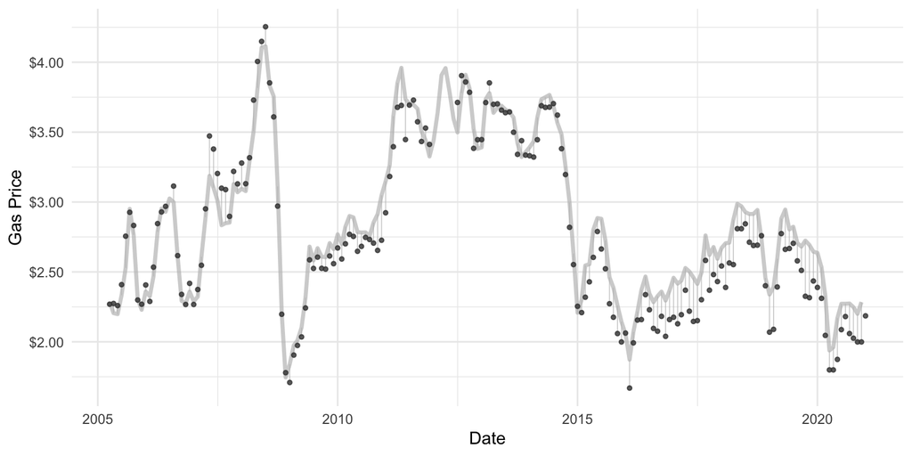

**Details: Seasonality**

The seasonal fluctuations in the gas prices amount to **$0.44** , with the peak price in **July** , and the lowest in **February** .

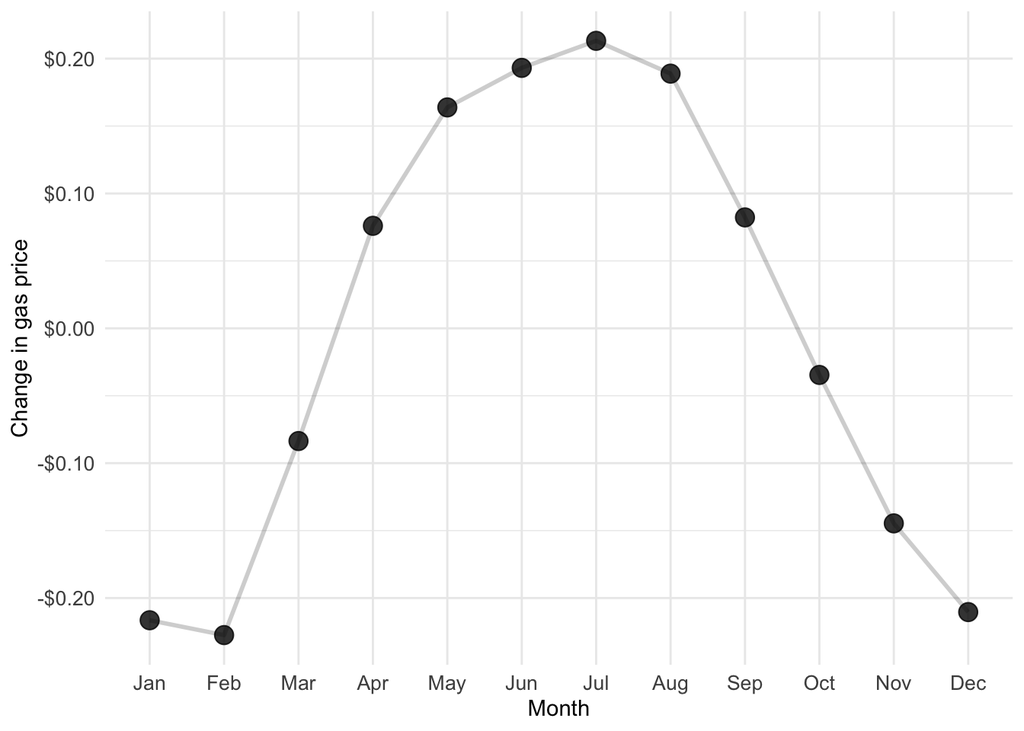